# Benchmark de librerías de álgebra lineal en R

Dante Ruiz 183340 y Laura López 144089 (Equipo13)

2/14/2019

## Introducción

A continuación se presentan los resultados de un benchmark que se realizó para comparar el tiempo de ejecución de diferentes operaciones de álgebra lineal utilizando diferentes compilaciones de R.

## Procedimiento

El ejercicio se realizó utilizando contenedores de Docker utilizando una imagen de Ubuntu 18.04. Por lo que para hacer replicable este procedimiento se asume que el usuario tiene instalado Docker y descargado la imagen de Ubuntu como se muestra a continuación.

```bash
docker pull ubuntu
```

En cada contenedor de Docker se hace una instalación limpia de la base de R, sobre la cual se instalaran en distintas librerías de álgebra lineal para compilar el paquete estadístico.

Para este benchmark se construyeron cuatro contenedores con las siguientes características:

1. *R-Base:* Ubuntu 18.04 + R-base 3.4.4
2. *R con openblas:* Ubuntu 18.04 + R-base 3.4.4 + libopenblas-base
3. *R con atlas:* Ubuntu 18.04 + R-base 3.4.4 + libatlas-base-dev
4. *R con lapack:* Ubuntu 18.04 + R-base 3.4.4 + liblapacke-dev

Para evaluar el desempeño de cada una de las configuraciones de R con las distintas librerías de álgebra lineal se realizaron ocho pruebas:

1. Multiplicación de dos vectores
2. Multiplicación de matriz por vector
3. Multiplicación de una matriz por una matriz
4. Calcular los eigen valores de una matriz
5. Invertir una matriz
6. Resolver un sistema de ecuaciones lineales
7. Análisis de componentes principales
8. Descomposición de valores singulares de una matriz

Estas pruebas fueron realizadas con una matriz M de tamaño 2500 x 2500 utilizando valores aleatorios de una distribución uniforme. Las variables aleatorias que se extrajeron de la distribución uniforme toman valores entre 0 y 1000.

Lo que mide cada una de las pruebas es el tiempo que tarda el CPU del usuario en procesar las operaciones. La función que se utilizó en R es la de **system.time()**. Específicamente analizará el resultado de user.self

A continuación se muestra el código que se utilizó en las cuatro pruebas:

```r
# Comienza prueba
print("Test started!")

# Fijar el tamaño de las matrices y vectores
tamano <- 2500

# Multiplicación de dos vectores
x <- runif(tamano,0,1000)
# Se crea una vector de 1000 x 1 y adicionalmente se perturba con valores aleatorios entre 250 y 750
y <- runif(tamano,0,1000) + runif(1,250,750)

print("t1...")
t1 <- system.time({
  x %*% y
})

# Crear una matriz de 2500 x 2500 utilizando números aleatorios de una distribución uniforme.
set.seed(1234)
M<-matrix(runif(tamano*tamano,min=0,1000),tamano,tamano)

# Mutiplicación de matriz por vector
print("t2...")
t2 <- system.time({
  M %*% x
})

# Multiplicación de una matriz por una matriz
print("t3...")
t3 <- system.time({
  (M %*% t(M))
})

# Calcular los eigen valores de una matriz
print("t4...")
t4 <- system.time({
  eigen(M)
})

# Invertir una matriz
print("t5...")
t5 <- system.time({
  solve(M)
})

# Resolver un sistema de ecuaciones lineals
print("t6...")
t6 <- system.time({
  solve(M,y)
})

# Análisis de componentes principales
print("t7...")
t7 <- system.time({
  princomp(M)
})

# Descomposición de valores singulares
print("t8...")
t8 <- system.time({
  svd(M)
})

# Escribir los resultados en un csv
tiempos <- as.data.frame(rbind(t1,t2,t3,t4,t5,t6,t7,t8))
write.csv(tiempos, "resultados_prueba.csv")

# Termina prueba
print("Test finished!")
```

Los resultados de cada una de las pruebas se guarda en los subdirectorios utilizando el nombre de **resultados_prueba.csv**.

## Configuración de contenedores

A continuación se muestra como configurar cada uno de los contenedores desde la terminal de bash o docker.

Cada uno de los contenedores se encuentra ligado a un volumen local con el **directorio benchmarks** en la máquina local que contiene **cuatro subdirectorios**:

1. rbase
2. openblass
3. atlas
4. lapack

### Primer docker solo con r-base

Sustituir por la ruta al directorio benchmarks creado en la máquina local. Dicho directorio debe contener el **subdirectorio rbase** el cual contiene el **script.R** para realizar el benchmark.

```bash
# Primer docker solo con r-base
docker run --rm -it -v <ruta_local_a_directorio_benchmarks>:/data ubuntu /bin/bash
apt-get update
apt-get install sudo
sudo apt-get install r-base
cd /data/rbase/
Rscript script.R
exit
```

### Segundo docker con r-base y open-blas

Sustituir por la ruta al directorio benchmarks creado en la máquina local. Dicho directorio debe contener el **subdirectorio openblass** el cual contiene el **script.R** para realizar el benchmark.

```bash
# Segundo docker con r-base y open-blas
docker run --rm -it -v <ruta_local_a_directorio_benchmarks>:/data ubuntu /bin/bash
apt-get update
apt-get install sudo
sudo apt-get install r-base
sudo apt-get install libopenblas-base r-base
cd /data/openblass/
Rscript script.R
exit
```

### Tercer docker con r-base y atlas

Sustituir por la ruta al directorio benchmarks creado en la máquina local. Dicho directorio debe contener el **subdirectorio atlas** el cual contiene el **script.R** para realizar el benchmark.

```bash
# Tercer docker con r-base y atlas
docker run --rm -it -v <ruta_local_a_directorio_benchmarks>:/data ubuntu /bin/bash
apt-get update
apt-get install sudo
sudo apt-get install r-base
sudo apt-get install libatlas-base-dev
cd /data/atlas/
Rscript script.R
exit
```

### Cuarto docker con r-base y lapack

```bash
# Cuarto docker con r-base y lapack
docker run --rm -it -v <ruta_local_a_directorio_benchmarks>:/data ubuntu /bin/bash
apt-get update
apt-get install sudo
sudo apt-get install r-base
sudo apt-get install liblapacke-dev
cd /data/lapack/
Rscript script.R
exit
```

## Resultados

A continuación se muestran los resultados del benchmark realizados a cada una de las configuraciones de R con la librerías de álgebra lineal.

Este análisis no se realizó en ningún Docker, ya que instalar paquetes para el análisis y gráficas toma más tiempo. En este sentido, el análisis de los resultados se realizó con la versión de R en la máquina local y utilizando la librería **tidyverse**.

En el siguiente código se recuperan los archivos **resultados_prueba.csv** de los distintos subidrectorios: rbase, openblass, atlas, lapack.

```r
library(tidyverse)

# Leer los datos de cada prueba
datos_rbase <- read_csv("rbase/resultados_prueba.csv")
datos_openblass <- read_csv("openblass/resultados_prueba.csv")
datos_atlas <- read_csv("atlas/resultados_prueba.csv")
datos_lapack <- read_csv("lapack/resultados_prueba.csv")

# Poner el nombre de la prueba
datos_rbase <- datos_rbase %>% mutate(configuracion = "ubuntu_r_base") %>% rename("prueba" = X1)
datos_openblass <- datos_openblass %>% mutate(configuracion = "ubuntu_openblas") %>% rename("prueba" = X1)
datos_atlas <- datos_atlas %>% mutate(configuracion = "ubuntu_atlas") %>% rename("prueba" = X1)
datos_lapack <- datos_lapack %>% mutate(configuracion = "ubuntu_lapack") %>% rename("prueba" = X1)

# Juntar los resultados en un data frame
datos <- rbind(datos_rbase,datos_openblass,datos_atlas, datos_lapack)
```

Una vez recuperados los archivos se juntan en un solo data frame para ser analizados de manera gráfica.

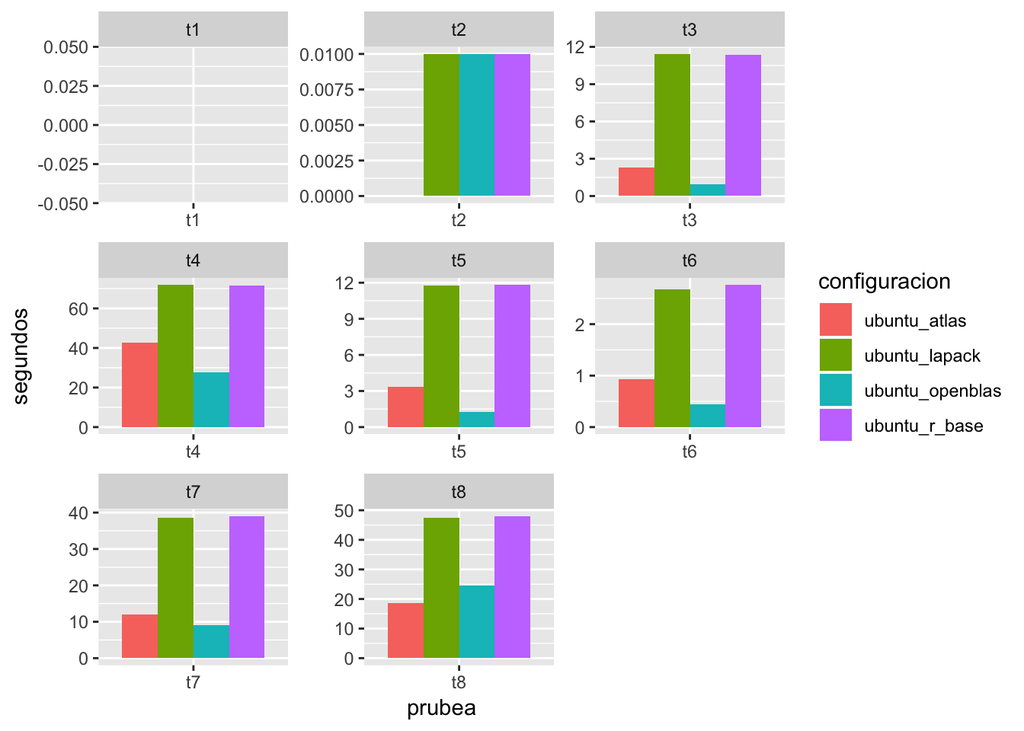

```r
# Graficar resultados
ggplot(datos, aes(x=prueba, y=user.self)) +
  geom_bar(stat = 'identity', aes(fill = configuracion), position = "dodge") +
  xlab("prubea") +
  ylab("segundos") +
  facet_wrap(~prueba, scales = "free")
```

Nombre de las pruebas:

- t1: Multiplicación de dos vectores

El producto punto de dos vectores es una operación muy rápida en las cuatro configuraciones de R, al punto que no se observan diferencias en eficiencia significativas.

```r
datos %>% select(prueba, configuracion, user.self, sys.self, elapsed) %>% filter(prueba == "t1") %>% arrange(prueba, user.self)
```

```
## # A tibble: 4 x 5
##   prueba configuracion   user.self sys.self elapsed
##   <chr>  <chr>               <dbl>    <dbl>   <dbl>
## 1 t1     ubuntu_r_base           0        0       0
## 2 t1     ubuntu_openblas         0        0       0
## 3 t1     ubuntu_atlas            0        0       0
## 4 t1     ubuntu_lapack           0        0       0
```

- t2: Multiplicación de matriz por vector

```r
datos %>% select(prueba, configuracion, user.self, sys.self, elapsed) %>% filter(prueba == "t2") %>% arrange(prueba, user.self)
```

```
## # A tibble: 4 x 5
##   prueba configuracion   user.self sys.self elapsed
##   <chr>  <chr>               <dbl>    <dbl>   <dbl>
## 1 t2     ubuntu_atlas      0           0.01 0.00900
## 2 t2     ubuntu_r_base     0.01000     0    0.01000
## 3 t2     ubuntu_lapack     0.01000     0    0.00900
## 4 t2     ubuntu_openblas   0.01        0    0.007
```

- t3: Multiplicación de una matriz por una matriz

El producto punto entre dos matrices en este caso la matriz M por su matriz traspuesta es una operación relativamente sencilla. La configuración más eficiente fue openblas y la segunda más eficiente atlas.

```r
datos %>% select(prueba, configuracion, user.self, sys.self, elapsed) %>% filter(prueba == "t3") %>% arrange(prueba, user.self)
```

```
## # A tibble: 4 x 5
##   prueba configuracion   user.self sys.self elapsed
##   <chr>  <chr>               <dbl>    <dbl>   <dbl>
## 1 t3     ubuntu_openblas      0.95     0.22   0.325
## 2 t3     ubuntu_atlas         2.31     0.04   2.36
## 3 t3     ubuntu_r_base       11.3      0.03  11.4
## 4 t3     ubuntu_lapack       11.4      0.04  11.5
```

- t4: Calcular los eigen valores de una matriz

El cálculo de eigen valores de una matriz fue la operación más demandante. La configuración más rápida fue openblas, seguida de atlas.

```r
datos %>% select(prueba, configuracion, user.self, sys.self, elapsed) %>% filter(prueba == "t4") %>% arrange(prueba, user.self)
```

```
## # A tibble: 4 x 5
##   prueba configuracion   user.self sys.self elapsed
##   <chr>  <chr>               <dbl>    <dbl>   <dbl>
## 1 t4     ubuntu_openblas      27.6    11.7     10.1
## 2 t4     ubuntu_atlas         42.8     0.15    43.1
## 3 t4     ubuntu_r_base        71.6     0.08    71.8
## 4 t4     ubuntu_lapack        71.8     0.12    72.0
```

- t5: Invertir una matriz

```r
datos %>% select(prueba, configuracion, user.self, sys.self, elapsed) %>% filter(prueba == "t5") %>% arrange(prueba, user.self)
```

```
## # A tibble: 4 x 5
##   prueba configuracion   user.self sys.self elapsed
##   <chr>  <chr>               <dbl>    <dbl>   <dbl>
## 1 t5     ubuntu_openblas      1.25     0.19   0.401
## 2 t5     ubuntu_atlas         3.34     0.04   3.38
## 3 t5     ubuntu_lapack       11.8      0.04  11.8
## 4 t5     ubuntu_r_base       11.8      0.04  11.9
```

- t6: Resolver un sistema de ecuaciones lineales

Openblas y atlas son las configuraciones más rápidas para resolver el sistema de ecuaciones lineales.

```r
datos %>% select(prueba, configuracion, user.self, sys.self, elapsed) %>% filter(prueba == "t6") %>% arrange(prueba, user.self)
```

```
## # A tibble: 4 x 5
##   prueba configuracion   user.self sys.self elapsed
##   <chr>  <chr>               <dbl>    <dbl>   <dbl>
## 1 t6     ubuntu_openblas      0.44     0.17   0.153
## 2 t6     ubuntu_atlas         0.93     0.02   0.947
## 3 t6     ubuntu_lapack        2.67     0.02   2.66
## 4 t6     ubuntu_r_base        2.76     0.01   2.78
```

- t7: Análisis de componentes principales

El cálculo de análisis de componentes principales es una operación demandante y las configuraciones openblas y atlas fueron las más eficientes hasta cuatro veces.

```r
datos %>% select(prueba, configuracion, user.self, sys.self, elapsed) %>% filter(prueba == "t7") %>% arrange(prueba, user.self)
```

```
## # A tibble: 4 x 5
##   prueba configuracion   user.self sys.self elapsed
##   <chr>  <chr>               <dbl>    <dbl>   <dbl>
## 1 t7     ubuntu_openblas       9.1     2.04    3.74
## 2 t7     ubuntu_atlas         12.0     0.35   12.4
## 3 t7     ubuntu_lapack        38.6     0.19   38.8
## 4 t7     ubuntu_r_base        39.0     0.31   39.4
```

- t8: Descomposición de valores singulares de una matriz

La descomposición de valores singulares de una matriz es también una operación demandante. La configuración de atlas y openblas fueron más eficientes que sus contrapartes hasta dos y media veces.

```r
datos %>% select(prueba, configuracion, user.self, sys.self, elapsed) %>% filter(prueba == "t8") %>% arrange(prueba, user.self)
```

```
## # A tibble: 4 x 5
##   prueba configuracion   user.self sys.self elapsed
##   <chr>  <chr>               <dbl>    <dbl>   <dbl>
## 1 t8     ubuntu_atlas         18.6     0.14   18.7
## 2 t8     ubuntu_openblas      24.7     4.55    7.63
## 3 t8     ubuntu_lapack        47.5     0.12   47.7
## 4 t8     ubuntu_r_base        48.0     0.15   48.2
```

## Conclusión

En general las librerías de álgebra lineal openblas y atlas fueron las más eficientes para las ocho pruebas que se realizaron. Es posible observar sus bondades en la medida que incrementa la escala de los datos, particularmente en operaciones más complicadas.